# Description Caaban Project

## Reading the DCC files

(following GeomxSet_coercions.html vignette from “D:/oldComputer/trainingStuff/coursera/BIOINFO_Courses/scRNA-seq/fost_Seurat/NanoString”)

```r
# load packages
library(GeomxTools)
library(Seurat)
library(SpatialExperiment)
library(SpatialDecon)
library(patchwork) # combine separate ggplots into the same graphic
library(RColorBrewer)
library(celldex)
library(SingleR)
library(dplyr)
dr="//derelict/hpc-prj/wren/chaaban_scRNAspatial/allDCC/"
```

## Read

```r
############ read All DCC files at once ##########

dr="//derelict/hpc-prj/wren/chaaban_scRNAspatial/allDCC/"
DCCFiles <- dir(dr, pattern=".dcc$", full.names=TRUE);
#PKCFiles <- unzip(zipfile = file.path(dr,"/Hs_R_NGS_WTA_v1.0.pkc_.zip"))
PKCFiles="./Hs_R_NGS_WTA_v1.0.pkc"
SampleAnnotationFile<-file.path(dr,"ROIKeyAnno_BothSet.xlsx")

objData12=suppressWarnings(readNanoStringGeoMxSet(dccFiles=DCCFiles,pkcFiles=PKCFiles[1],phenoDataFile=SampleAnnotationFile,phenoDataSheet="29June2021_CTA_20210630T1934_La",phenoDataDccColName="Sample_ID",protocolDataColNames=c("aoi","NECType","roi","area","segment","Patient","segType")))

pData(objData12)$Set=c("Fr","Sc")[1*(sData(objData12)$Patient%in%c(5:7))+1]

# access objData12 components
# objData12 # NanoStringGeoMxSet object ; assayData: 18815 features, 56 samples
# mat=exprs(objData12);dim(mat) # 18815 56
# colData=sData(objData12); dim(colData); # 56 27
# colnames(colData); # slide name; scan name; panel; Set; FileVersion; SoftwareVersion; Date; SampleID; Plate_ID; Well; SeqSetId; Raw; Trimmed; Stitched; Aligned; umiQ30; rtsQ30; DeduplicatedReads; roi; segment; aoi; area; NECType; Patient; segType; NTC_ID; NTC
# table(colData$Patient,colData$segType)
# table(colData$Set,colData$Patient)

# QC filtering
objData12<- shiftCountsOne(objData12, useDALogic=TRUE) # Shift all 0 counts by 1  (package GeomxTools)
objData12<-setSegmentQCFlags(objData12, qcCutoffs = list(percentSaturation = 45)) # QCFlags data frame appended to protocolData ;
objData12<-setBioProbeQCFlags(objData12) # Add probe QC flags to object feature data
lowSaturation <- which(protocolData(objData12)[["QCFlags"]]$LowSaturation) # low sequenced ROIs
lowQCprobes <- which(featureData(objData12)[["QCFlags"]]$LowProbeRatio |featureData(objData12)[["QCFlags"]]$GlobalGrubbsOutlier) # probes considered outliers
#passedQC <- objData12[-lowQCprobes, -lowSaturation]
passedQC <- objData12 # no features/ROIs with low quality
assayDataElementNames(passedQC) # "exprs" "preLocalRemoval" "rawZero" # same as names(assayData(passedQC)) all 18815 56 matrices

# need to aggregated to Target level data before coercing.  (Changes row form probe ID to gene name; aggregate multiple probes per gene)
featureType(passedQC) # Probe
table(table(fData(passedQC)[,"TargetName"])) # there are multiple rows (probes) for each gene ("TargetName" column in fData data frame)
target_demoData <- aggregateCounts(passedQC) # use TargetName column of fData, aggregate on it
featureType(target_demoData) # "Target" (row name of exprs(target_demoData) become gene names)

# 3.    normalize, before coercing to Seurat, using a GeoMx specific model (recommended), rather than use Seurat normalization after)
norm_target_demoData <- normalize(target_demoData, norm_method="quant", desiredQuantile = .75, toElt = "q_norm") # normalized data in assayData slot “q_norm”;
#norm_target_demoData <- normalize(target_demoData, norm_method="Housekeeping-Log2", toElt = "q_norm") # normalized data in assayData slot “q_norm”;
assayDataElementNames(norm_target_demoData) # "exprs" "q_norm"

#   Seurat Coercion
#demoSeurat <- as.Seurat(norm_target_demoData, normData = "q_norm") # input need to be aggregated on Target; normalized (can force raw input with forceRaw=TRUE); correct name of norm Data specified;
objSeurat <- as.Seurat(norm_target_demoData, normData = "q_norm", ident = "segType")
```

Initially I got Differentially expressed genes using voom/limma as if I had bulkRna data. First version of umap was done directly using library(umap) on “vobjDream$E” matrix (see myCode.txt inside chaaban_scRNAspatial folder).

## SCTransform normalization followed by UMAP and Clustering

Below there is a diffrent umap picture made after renormalizing the seurat object with SCT and going trough standard pipeline (it merge better the two sets of DCC files, patients 1,2,3,4 respectively patients 5,6,7)

```r
## SCTransform normalization followed by UMAP and Clustering
CDPreAdj=(objSeurat$segType=="CDPre")*(1-2*(objSeurat$Set=="Fr"))
CDPreAdj[CDPreAdj>0]=1/sum(CDPreAdj[CDPreAdj>0]);CDPreAdj[CDPreAdj<0]=1/sum(CDPreAdj[CDPreAdj<0])
PanPreAdj=(objSeurat$segType=="PanPre")*(1-2*(objSeurat$Set=="Fr"))
PanPreAdj[PanPreAdj>0]=1/sum(PanPreAdj[PanPreAdj>0]);PanPreAdj[PanPreAdj<0]=1/sum(PanPreAdj[PanPreAdj<0])
#CDPreAdj=(objSeurat$segType=="CDPre")*(objSeurat$Set=="Fr")
#PanPreAdj=(objSeurat$segType=="PanPre")*(objSeurat$Set=="Fr")
objSeurat$CDPreAdj=CDPreAdj
objSeurat$PanPreAdj=PanPreAdj
objSeurat<-SCTransform(objSeurat,method="glmGamPoi",vars.to.regress=c("CDPreAdj","PanPreAdj","nFeature_GeoMx"),verbose=FALSE,assay="GeoMx")

objSeurat <- RunPCA(objSeurat, verbose = FALSE,npcs=25)
objSeurat <- RunUMAP(objSeurat, dims = 1:24, verbose = FALSE,n.components=2) # use 30 PCs instead of 10 for downstream
objSeurat <- FindNeighbors(objSeurat, dims = 1:24, verbose = FALSE,k.param = 10) # parameter reduction = 'pca' (default) selects which dim reduction to use
objSeurat <- FindClusters(objSeurat, verbose = FALSE)
objSeurat[["umap"]]@cell.embeddings=objSeurat[["umap"]]@cell.embeddings[,2:1];
objSeurat[["umap"]]@cell.embeddings[,1]=-objSeurat[["umap"]]@cell.embeddings[,1];
colnames(objSeurat[["umap"]]@cell.embeddings)=colnames(objSeurat[["umap"]]@cell.embeddings)[2:1]

objSeurat$seurat_clusters=factor(c(2,3,1)[as.numeric(objSeurat$seurat_clusters)])
table(objSeurat$segType,objSeurat$seurat_clusters)
# separae PanPre and CDPre in 2 groups each
segTypeClst=objSeurat$segType;segTypeClst[segTypeClst=="PanPre"&objSeurat$seurat_clusters==2]="PanPre_1";segTypeClst[segTypeClst=="CDPre"&objSeurat$seurat_clusters==1]="CDPre_1";
objSeurat$segTypeClst=segTypeClst

save(objSeurat,file="objSeurat_UMAPs.rda")
```

## Describing objSeurat

```r
load("objSeurat_UMAPs.rda")
objSeurat # Seurat object, 18677 features 56 samples 1 assay (Active assay: GeoMx)
```

```
## An object of class Seurat
## 37354 features across 56 samples within 2 assays
## Active assay: SCT (18677 features, 3000 variable features)
##  1 other assay present: GeoMx
##  2 dimensional reductions calculated: pca, umap
```

```r
names(objSeurat) # "GeoMx" "SCT" "SCT_nn" "SCT_snn" "pca" "umap"
```

```
## [1] "GeoMx"   "SCT"     "SCT_nn"  "SCT_snn" "pca"     "umap"
```

```r
slotNames(objSeurat) # assays; meta.data; active.assay; active.ident; graphs; neighbors; reductions; images; project.name; misc; version; commands; tools
```

```
##  [1] "assays"       "meta.data"    "active.assay" "active.ident" "graphs"
##  [6] "neighbors"    "reductions"   "images"       "project.name" "misc"
## [11] "version"      "commands"     "tools"
```

```r
#Assays(objSeurat) #  "GeoMx" # not working
names(objSeurat@reductions) # "pca"  "umap"
```

```
## [1] "pca"  "umap"
```

```r
# access
names(objSeurat@assays) # "GeoMx" (before normalization) # "GeoMx" "SCT" after SCTnomalize
```

```
## [1] "GeoMx" "SCT"
```

```r
objSeurat@assays[["GeoMx"]][1:2,1:5] # 18677 56 (normalized values, with .)
```

```
## 2 x 5 sparse Matrix of class "dgCMatrix"
##      DSP-1001660012684-C-F02.dcc DSP-1001660012684-C-F03.dcc
## A2M                     14.20455                   17.045459
## NAT2                     8.52273                    6.392047
##      DSP-1001660012684-C-F04.dcc DSP-1001660012684-C-F05.dcc
## A2M                    17.045459                     8.52273
## NAT2                    9.740263                     8.52273
##      DSP-1001660012684-C-F06.dcc
## A2M                      8.52273
## NAT2                     8.52273
```

```r
slotNames(objSeurat@assays[["GeoMx"]]) #  counts (18677 56); data (18677 56); scale.data (0 0); key; assay.orig; var.features; meta.features; misc
```

```
## [1] "counts"        "data"          "scale.data"    "key"
## [5] "assay.orig"    "var.features"  "meta.features" "misc"
```

```r
slotNames(objSeurat[["GeoMx"]]) # same as slotNames(objSeurat@assays[["GeoMx"]])
```

```
## [1] "counts"        "data"          "scale.data"    "key"
## [5] "assay.orig"    "var.features"  "meta.features" "misc"
```

```r
slotNames(objSeurat@assays[["SCT"]]) # SCTModel.list; counts (18677 56); data (18677 56); scale.data (3000 56); key; assay.orig; var.features; meta.features; misc
```

```
## [1] "SCTModel.list" "counts"        "data"          "scale.data"
## [5] "key"           "assay.orig"    "var.features"  "meta.features"
## [9] "misc"
```

```r
head(objSeurat, 3) # most important ROI metadata 56 24
```

```
##                             orig.ident nCount_GeoMx nFeature_GeoMx
## DSP-1001660012684-C-F02.dcc                164831.4          18677
## DSP-1001660012684-C-F03.dcc                172338.2          18677
## DSP-1001660012684-C-F04.dcc                157275.3          18677
##                                     slide.name          scan.name
## DSP-1001660012684-C-F02.dcc CS13-1240 CS15-843 CS13-1240 CS15-843
## DSP-1001660012684-C-F03.dcc CS13-1240 CS15-843 CS13-1240 CS15-843
## DSP-1001660012684-C-F04.dcc CS13-1240 CS15-843 CS13-1240 CS15-843
##                                                                      panel Set
## DSP-1001660012684-C-F02.dcc (v1.0) Human NGS Whole Transcriptome Atlas RNA  Sc
## DSP-1001660012684-C-F03.dcc (v1.0) Human NGS Whole Transcriptome Atlas RNA  Sc
## DSP-1001660012684-C-F04.dcc (v1.0) Human NGS Whole Transcriptome Atlas RNA  Sc
##                             NegGeoMean_Hs_R_NGS_WTA_v1.0
## DSP-1001660012684-C-F02.dcc                     4.950158
## DSP-1001660012684-C-F03.dcc                     2.061288
## DSP-1001660012684-C-F04.dcc                     3.449893
##                             NegGeoSD_Hs_R_NGS_WTA_v1.0 q_norm_qFactors
## DSP-1001660012684-C-F02.dcc                   1.781202       1.0559997
## DSP-1001660012684-C-F03.dcc                   1.921194       0.4693332
## DSP-1001660012684-C-F04.dcc                   1.870801       0.8213331
##                                            SampleID roi segment          aoi
## DSP-1001660012684-C-F02.dcc DSP-1001660012684-C-F02 1_5   CD45+ CD45-aoi-001
## DSP-1001660012684-C-F03.dcc DSP-1001660012684-C-F03 2_5   CD45+ CD45-aoi-001
## DSP-1001660012684-C-F04.dcc DSP-1001660012684-C-F04 3_5   CD45+ CD45-aoi-001
##                                 area NECType Patient segType   CDPreAdj
## DSP-1001660012684-C-F02.dcc 42977.28 Preterm       5   CDPre 0.07142857
## DSP-1001660012684-C-F03.dcc 25210.81 Preterm       5   CDPre 0.07142857
## DSP-1001660012684-C-F04.dcc 26841.73 Preterm       5   CDPre 0.07142857
##                             PanPreAdj nCount_SCT nFeature_SCT SCT_snn_res.0.8
## DSP-1001660012684-C-F02.dcc         0     167667        18677               2
## DSP-1001660012684-C-F03.dcc         0     161126        18677               2
## DSP-1001660012684-C-F04.dcc         0     165156        18677               2
##                             seurat_clusters segTypeClst CellType
## DSP-1001660012684-C-F02.dcc               1     CDPre_1  T_cells
## DSP-1001660012684-C-F03.dcc               1     CDPre_1  T_cells
## DSP-1001660012684-C-F04.dcc               1     CDPre_1   B_cell
```

```r
colnames(head(objSeurat, 3)) # orig.ident; nCount_GeoMx; nFeature_GeoMx; slide.name; scan.name; panel; Set; NegGeoMean_Hs_R_NGS_WTA_v1.0; NegGeoSD_Hs_R_NGS_WTA_v1.0; q_norm_qFactors; SampleID; roi; segment; aoi; area; NECType; Patient; segType; CDPreAdj; PanPreAdj; nCount_SCT; nFeature_SCT; SCT_snn_res.0.8; seurat_clusters
```

```
##  [1] "orig.ident"                   "nCount_GeoMx"
##  [3] "nFeature_GeoMx"               "slide.name"
##  [5] "scan.name"                    "panel"
##  [7] "Set"                          "NegGeoMean_Hs_R_NGS_WTA_v1.0"
##  [9] "NegGeoSD_Hs_R_NGS_WTA_v1.0"   "q_norm_qFactors"
## [11] "SampleID"                     "roi"
## [13] "segment"                      "aoi"
## [15] "area"                         "NECType"
## [17] "Patient"                      "segType"
## [19] "CDPreAdj"                     "PanPreAdj"
## [21] "nCount_SCT"                   "nFeature_SCT"
## [23] "SCT_snn_res.0.8"              "seurat_clusters"
## [25] "segTypeClst"                  "CellType"
```

```r
dim(objSeurat@meta.data) #  56 24 # the file above (like pData) – ROI metadata
```

```
## [1] 56 26
```

```r
head(objSeurat@assays$GeoMx@meta.features) # gene metadata 18677 6; colnames: TargetName; Module; CodeClass; GeneID; SystematicName; Negative
```

```
##        TargetName            Module  CodeClass GeneID SystematicName Negative
## A2M           A2M Hs_R_NGS_WTA_v1.0 Endogenous      2            A2M    FALSE
## NAT2         NAT2 Hs_R_NGS_WTA_v1.0 Endogenous     10           NAT2    FALSE
## ACADM       ACADM Hs_R_NGS_WTA_v1.0 Endogenous     34          ACADM    FALSE
## ACADS       ACADS Hs_R_NGS_WTA_v1.0 Endogenous     35          ACADS    FALSE
## ACAT1       ACAT1 Hs_R_NGS_WTA_v1.0 Endogenous     38          ACAT1    FALSE
## ACVRL1     ACVRL1 Hs_R_NGS_WTA_v1.0 Endogenous     94         ACVRL1    FALSE
```

## UMAPs

```r
#boxplot(objSeurat[["umap"]]@cell.embeddings[,"UMAP_1"]~objSeurat$Patient)
#boxplot(objSeurat[["umap"]]@cell.embeddings[,"UMAP_2"]~objSeurat$Patient)
load("objSeurat_UMAPs.rda")
#objSeurat$seurat_clusters=factor(c(2,3,1)[as.numeric(objSeurat$seurat_clusters)])
table(objSeurat$segType,objSeurat$seurat_clusters)
```

```
##
##           1  2  3
##   CDCar   5  2  0
##   CDPre   4 15  0
##   PanCar  6  1  0
##   PanPre  0  6 17
```

```r
## separae PanPre and CDPre in 2 groups each
#segTypeClst=objSeurat$segType;segTypeClst[segTypeClst=="PanPre"&objSeurat$seurat_clusters==2]="PanPre_1";segTypeClst[segTypeClst=="CDPre"&objSeurat$seurat_clusters==1]="CDPre_1";
#objSeurat$segTypeClst=segTypeClst
table(objSeurat$segTypeClst)
```

```
##
##    CDCar    CDPre  CDPre_1   PanCar   PanPre PanPre_1
##        7       15        4        7       17        6
```

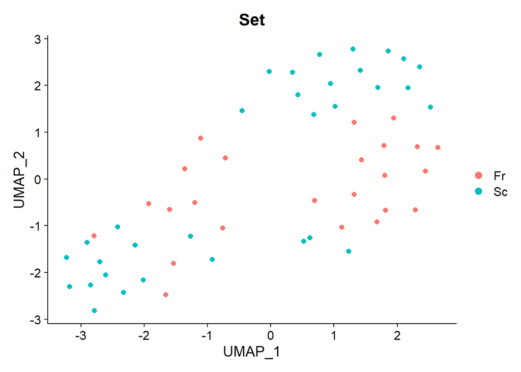

```r
DimPlot(objSeurat,label=F,group.by ="Set",dims = c(1, 2),pt.size=2)
```

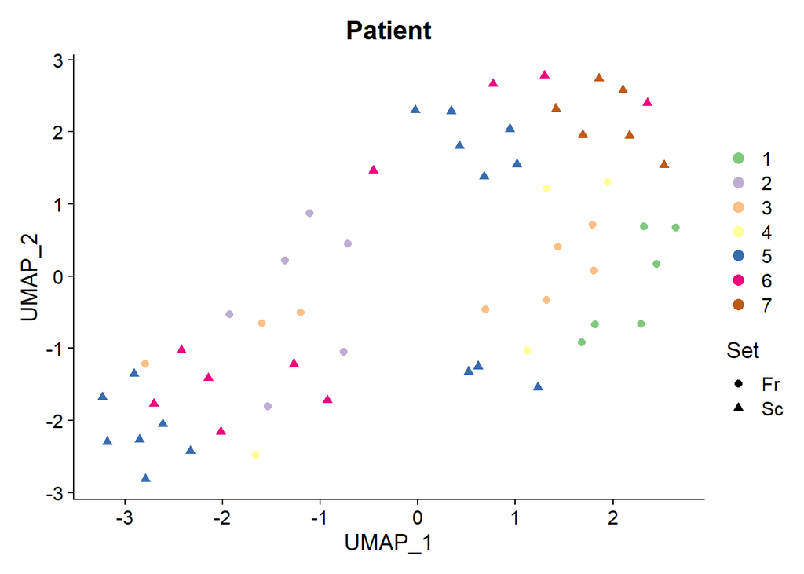

```r
DimPlot(objSeurat,label=F,group.by="Patient",dims=c(1,2),pt.size=2,shape.by="Set",cols = brewer.pal(length(unique(objSeurat$Patient)),"Accent"))
```

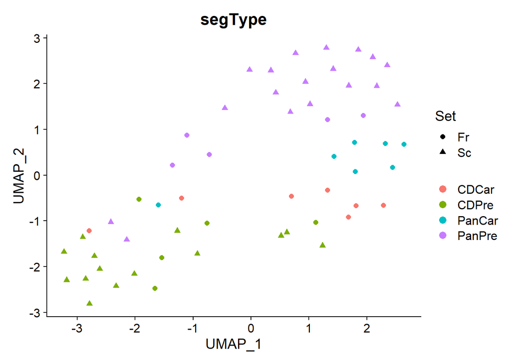

```r
DimPlot(objSeurat,label=F,group.by="segType",dims=c(1,2),pt.size=2,shape.by="Set")
```

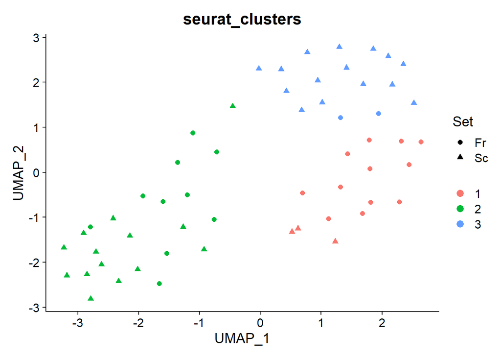

```r
DimPlot(objSeurat,label=F,group.by ="seurat_clusters",dims = c(1, 2),pt.size=2,shape.by="Set")
```

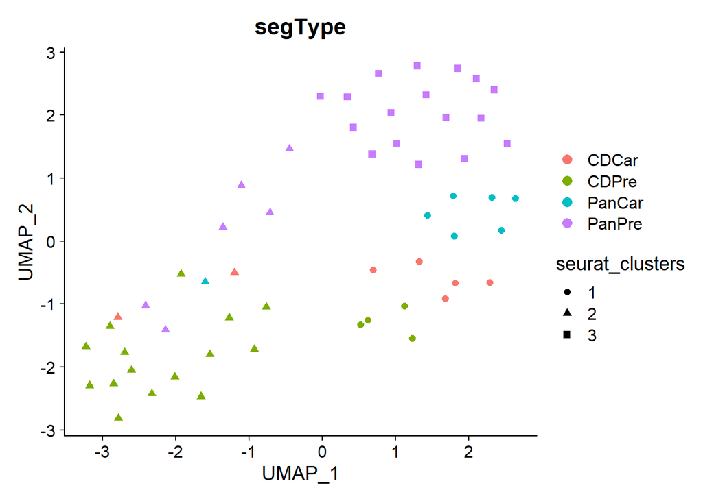

```r
#table(objSeurat$segType,objSeurat$seurat_clusters)
DimPlot(objSeurat,label=F,group.by="segType",dims=c(1,2),pt.size=2,shape.by="seurat_clusters")
```

```r
## separae PanPre and CDPre in 2 groups each
table(objSeurat$segTypeClst)
```

```
##
##    CDCar    CDPre  CDPre_1   PanCar   PanPre PanPre_1
##        7       15        4        7       17        6
```

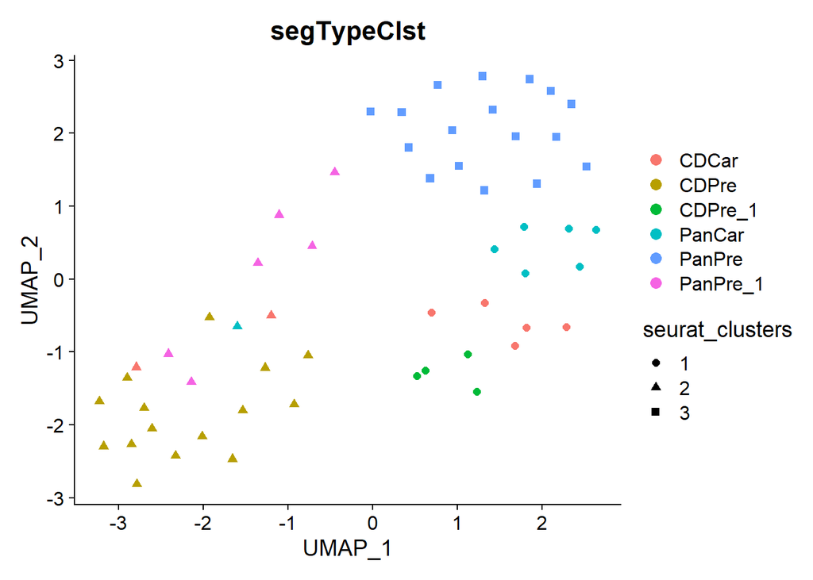

```r
DimPlot(objSeurat,label=F,group.by="segTypeClst",dims=c(1,2),pt.size=2,shape.by="seurat_clusters")
```

## Convolution with SpatialDecon

Follow SpatialDecon_vignette.html from fost_Seurat/NanoString folder.  
If we can add more than one matrix for convolution, the **Ileum_Wang** and **ImmuneTumor_safeTME** might be interesting—if not, the one you already selected (**Gut_HCA**) looks good. (See HumanAdult_CellTypes.xlsx file, in chaaban_scRNAspatial folder, listing the options for matrices)

```r
## NOT WORKING (but it did work last time, see how it was done)
library(Seurat)
library(SpatialDecon)
# download profile matrix from List: CellProfileLibrary GitHub Page (https://github.com/Nanostring-Biostats/CellProfileLibrary/tree/NewProfileMatrices) (use Gut_HCA.RData for your project)
# Elmentaite, R. et al. Cells of the human intestinal tract mapped across space and time. bioRxiv 2021.04.07.438755 (2021) doi:10.1101/2021.04.07.438755.
profileMat<-download_profile_matrix(species = "Human",age_group = "Adult",matrixname = "Gut_HCA")
head(cellGroups) # list describing cell types; uploaded by download_profile_matrix function
metadata # general info about mousespleen (also uploaded during download)
heatmap(sweep(profileMat, 1, apply(profileMat, 1, max), "/"),labRow = NA, margins = c(10, 5), cexCol = 0.7)
## profileMatCollapsed=collapseCellTypes(fit=profileMat,matching=cellGroups) # safeTME.matches – list name group, cell types (see above)

profileMat_Gut=profileMat;
cellGroups_Gut=cellGroups;

profileMat<-download_profile_matrix(species="Human",age_group="Adult",matrixname="Ileum_Wang"); profileMat_IW=profileMat;
cellGroups_IW=cellGroups;

profileMat<-download_profile_matrix(species="Human",age_group="Adult",matrixname="ImmuneTumor_safeTME");profileMat_TME=profileMat;cellGroups_TME=cellGroups;

norm=objSeurat@assays[["SCT"]]@data
# get background matrix
#bg=derive_GeoMx_background(norm = norm, probepool = rep(1,nrow(norm)),negnames="NegProbe-WTX") # using package function
per.observation.mean.neg = norm["NegProbe-WTX", ];
bg = sweep(norm * 0, 2, per.observation.mean.neg, "+")

#res1=spatialdecon(norm =as.matrix(norm), bg = bg, X = safeTME, cellmerges=safeTME.matches,raw=demoSeurat@assays[["GeoMx"]]@counts)
res1=spatialdecon(norm =as.matrix(norm), bg = bg, X =profileMat_Gut, cellmerges=cellGroups_Gut)
```

## Try cellDex

Used in Susan project

```r
# http://bioconductor.org/books/3.13/OSCA.basic/cell-type-annotation.html#assigning-cell-labels-from-reference-data
# https://bioconductor.org/packages/3.13/data/experiment/vignettes/celldex/inst/doc/userguide.html # lists options for ref data

cnts=GetAssayData(objSeurat,assay="SCT",slot="data")

library(celldex)
# ref <- BlueprintEncodeData() # Blueprint/ENCODE
ref <- HumanPrimaryCellAtlasData() # Human primary cell atlas (HPCA)
library(SingleR)
pred<-SingleR(test=cnts,ref=ref,labels=ref$label.main)
lbls=pred$labels
#baboon.combined.sct$CellType=lbls
predFine <- SingleR(test=cnts, ref=ref, labels=ref$label.fine)
lblsFine=predFine$labels

objSeurat$CellType=lbls
save(objSeurat,pred,file="objSeurat_UMAPs.rda")
```

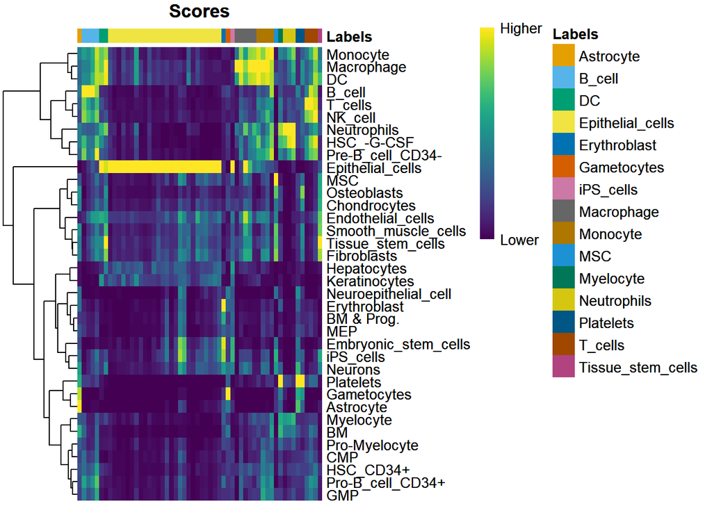

```r
load("objSeurat_UMAPs.rda")

plotScoreHeatmap(pred)
```

```r
lbls=objSeurat$CellType
table(objSeurat$CellType,objSeurat$seurat_clusters)
```

```
##
##                      1  2  3
##   Astrocyte          0  1  0
##   B_cell             4  0  0
##   DC                 0  2  0
##   Epithelial_cells   5  4 17
##   Erythroblast       0  1  0
##   Gametocytes        0  1  0
##   iPS_cells          1  0  0
##   Macrophage         1  4  0
##   Monocyte           2  2  0
##   MSC                0  1  0
##   Myelocyte          0  1  0
##   Neutrophils        0  3  0
##   Platelets          0  2  0
##   T_cells            2  1  0
##   Tissue_stem_cells  0  1  0
```

```r
table(objSeurat$CellType,objSeurat$segType)
```

```
##
##                     CDCar CDPre PanCar PanPre
##   Astrocyte             0     1      0      0
##   B_cell                2     2      0      0
##   DC                    0     0      1      1
##   Epithelial_cells      0     0      5     21
##   Erythroblast          0     1      0      0
##   Gametocytes           0     1      0      0
##   iPS_cells             0     0      1      0
##   Macrophage            2     3      0      0
##   Monocyte              3     0      0      1
##   MSC                   0     1      0      0
##   Myelocyte             0     1      0      0
##   Neutrophils           0     3      0      0
##   Platelets             0     2      0      0
##   T_cells               0     3      0      0
##   Tissue_stem_cells     0     1      0      0
```

```r
table(objSeurat$CellType,objSeurat$segTypeClst)
```

```
##
##                     CDCar CDPre CDPre_1 PanCar PanPre PanPre_1
##   Astrocyte             0     1       0      0      0        0
##   B_cell                2     0       2      0      0        0
##   DC                    0     0       0      1      0        1
##   Epithelial_cells      0     0       0      5     17        4
##   Erythroblast          0     1       0      0      0        0
##   Gametocytes           0     1       0      0      0        0
##   iPS_cells             0     0       0      1      0        0
##   Macrophage            2     3       0      0      0        0
##   Monocyte              3     0       0      0      0        1
##   MSC                   0     1       0      0      0        0
##   Myelocyte             0     1       0      0      0        0
##   Neutrophils           0     3       0      0      0        0
##   Platelets             0     2       0      0      0        0
##   T_cells               0     1       2      0      0        0
##   Tissue_stem_cells     0     1       0      0      0        0
```

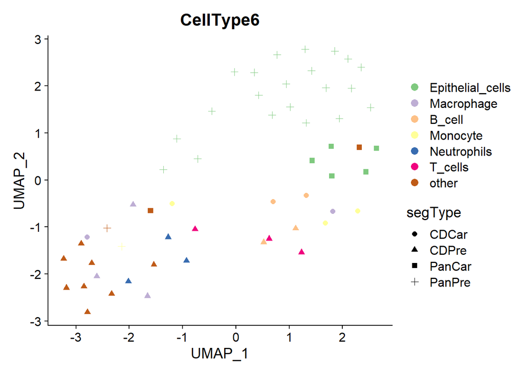

```r
tt=sort(table(objSeurat$CellType),decreasing=T);clk=names(tt[tt>2]);jjj=which(lbls%in%clk);clr=rep("other",length(lbls));clr[jjj]=lbls[jjj];objSeurat$CellType6=clr
DimPlot(objSeurat,label=F,group.by ="CellType6",dims = c(1, 2),pt.size=2,shape.by="segType",cols = brewer.pal(length(clk)+1,"Accent"),order = rev(c(clk,"other")))
```

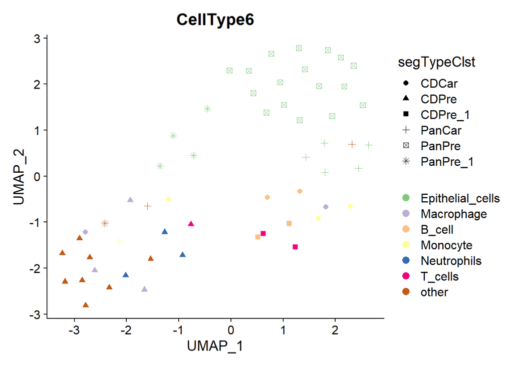

```r
DimPlot(objSeurat,label=F,group.by ="CellType6",dims = c(1, 2),pt.size=2,shape.by="segTypeClst",cols = brewer.pal(length(clk)+1,"Accent"),order = rev(c(clk,"other")))
```

## Caracterize Clusters

### Top genes segTypeClst

```r
# load("objSeurat_UMAPs.rda")
Idents(objSeurat)="segTypeClst"
markersAll=FindAllMarkers(objSeurat,assay="SCT",slot="data",only.pos = TRUE, min.pct = 0.25, logfc.threshold = 0.25)
#markersAll$t=qnorm(markersAll$p_val)*(1-2*(markersAll$avg_log2FC>0))
head(markersAll,n=3)
```

```
##               p_val avg_log2FC pct.1 pct.2 p_val_adj cluster   gene
## TRAC   0.0009211542   2.097611     1     1         1 CDPre_1   TRAC
## JAK3   0.0009302505   1.880572     1     1         1 CDPre_1   JAK3
## CORO1A 0.0009382593   2.230261     1     1         1 CDPre_1 CORO1A
```

```r
top10s=markersAll%>%group_by(cluster)%>%slice_min(n=6,order_by=p_val)
#print(top10s,n=3)
cbind(tapply(top10s$gene,top10s$cluster,function(x) paste0(x,collapse = ", ")))
```

```
##          [,1]
## CDPre_1  "TRAC, JAK3, CORO1A, CXCL13, LTB, LDHB"
## CDPre    "CSF3, SLCO1B7, PYGL, MCOLN2, F9, CATSPER3"
## PanPre   "LLGL2, FXYD3, SLC44A4, CLDN3, UQCRC1, PIGR"
## PanPre_1 "TAS2R45, TSNAX, MRGPRX1, GMPR, ELAVL4, KCNAB1"
## PanCar   "ACP1, ATP5MC2, FOXA1, SLC25A39, PERP, PKDCC"
## CDCar    "MYCBP2, HLA-DQB1, PARVG, ATM, DR1, CSAD"
```

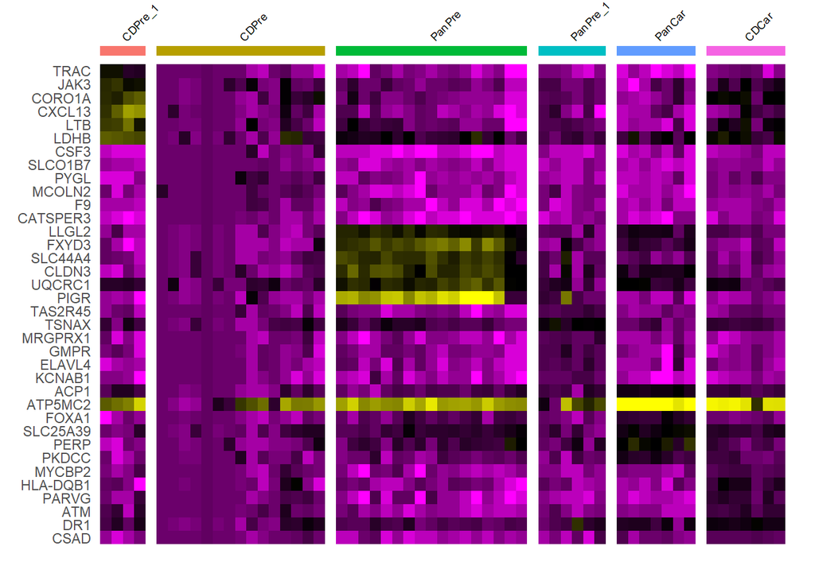

```r
DoHeatmap(object=objSeurat,features=top10s$gene,assay="SCT",slot="data",size=2.5,draw.lines=T)+NoLegend()
```

### Top genes segType

```r
# load("objSeurat_UMAPs.rda")
Idents(objSeurat)="segType"
markersAll=FindAllMarkers(objSeurat,assay="SCT",slot="data",only.pos = TRUE, min.pct = 0.25, logfc.threshold = 0.25)
#markersAll$t=qnorm(markersAll$p_val)*(1-2*(markersAll$avg_log2FC>0))
#head(markersAll)
top10s=markersAll%>%group_by(cluster)%>%slice_min(n=10,order_by=p_val)
#print(top10s,n=3)
cbind(tapply(top10s$gene,top10s$cluster,function(x) paste0(x,collapse = ", ")))
```

```
##        [,1]
## CDPre  "LRRC8C, ZNF224, TMC8, CD7, ZNF185, DGKA, IGHG2, TDO2, UCP2, MYH10"
## PanPre "PIGR, FAM3D, DHCR24, ATP10B, AOC1, UGT2B15, ELF3, TSPAN13, SCAMP2, TJP3"
## PanCar "ACP1, ATP5MC2, FOXA1, SLC25A39, PERP, PKDCC, AHCY, ARL6IP1, YKT6, MUC17"
## CDCar  "MYCBP2, HLA-DQB1, PARVG, ATM, DR1, CSAD, DENND4B, HLA-DPB1, CHST15, VOPP1"
```

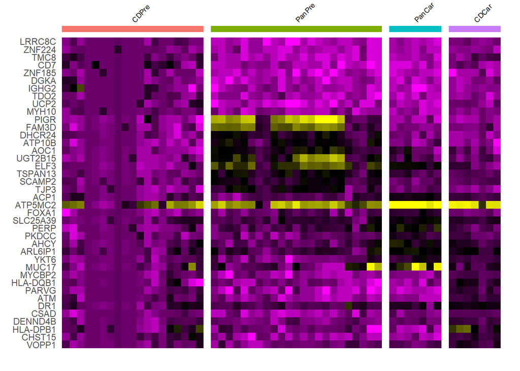

```r
DoHeatmap(object=objSeurat,features=top10s$gene,assay="SCT",slot="data",size=2.5,draw.lines=T)+NoLegend()
```

### PanPre_1 markers

```r
# load("objSeurat_UMAPs.rda")
Idents(objSeurat)="segTypeClst";
jjj=which(objSeurat$segTypeClst%in%c("PanPre_1","PanPre"))
#markers=FindMarkers(objSeurat[,jjj],assay="SCT",slot="data",only.pos = TRUE, min.pct=0.25, logfc.threshold=0.25,ident.1="PanPre_1",ident.2="PanPre" )
markers=FindMarkers(objSeurat[,jjj],assay="SCT",slot="data",only.pos = FALSE, min.pct=0.25, logfc.threshold=0.25,ident.1="PanPre_1",ident.2="PanPre" )
#markersAll$t=qnorm(markersAll$p_val)*(1-2*(markersAll$avg_log2FC>0))
#head(markersAll)
top10s=markers%>%slice_min(n=25,order_by=p_val)
#print(top10s,n=3)
paste0(row.names(top10s),collapse = ", ")
```

```
## [1] "ZNF311, NFE2, UBQLN4, CCIN, PNOC, KDELR1, RAB2A, COX7C, TAGLN2, YWHAE, C19orf33, DDX39B, CST3, H2AC11, LLGL2, EIF3K, CTNND1, LGALS3, COX6C, ELOB, ARF1, VAMP8, HLA-E, HNRNPU, XBP1"
```

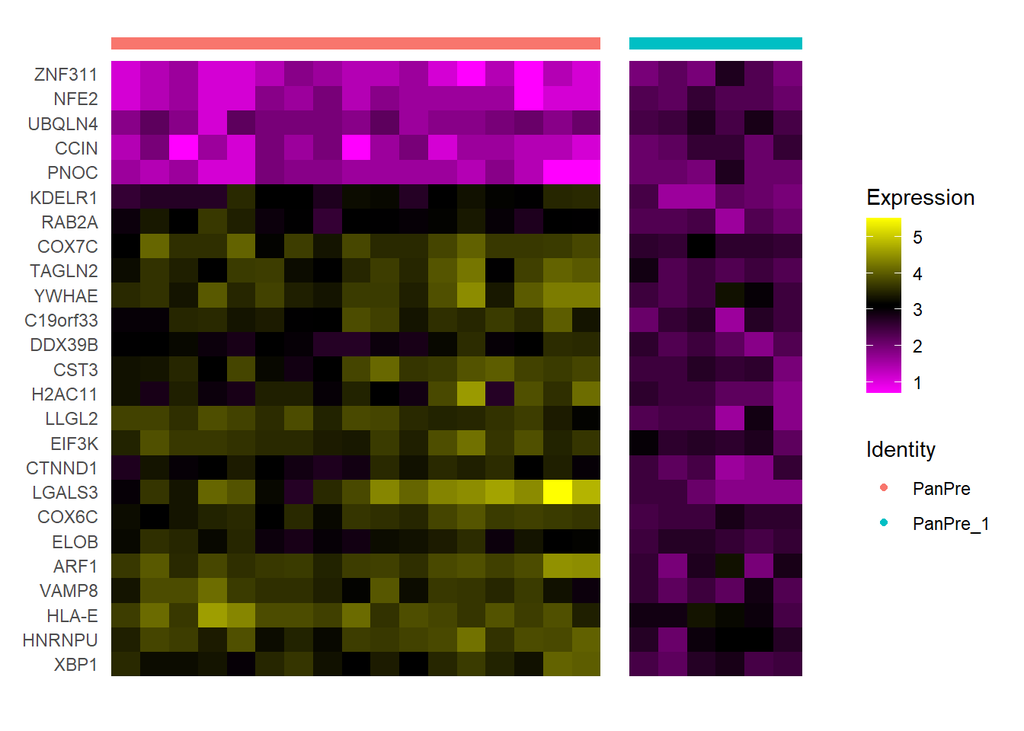

```r
DoHeatmap(object=objSeurat[,jjj],features=row.names(top10s),assay="SCT",slot="data",size=2.5,draw.lines=T,label=F)
```

### CDPre_1 markers

```r
# load("objSeurat_UMAPs.rda")
Idents(objSeurat)="segTypeClst";
jjj=which(objSeurat$segTypeClst%in%c("CDPre_1","CDPre"))
#markers=FindMarkers(objSeurat[,jjj],assay="SCT",slot="data",only.pos = TRUE, min.pct=0.25, logfc.threshold=0.25,ident.1="CDPre_1",ident.2="CDPre" )
markers=FindMarkers(objSeurat[,jjj],assay="SCT",slot="data",only.pos =FALSE, min.pct=0.25, logfc.threshold=0.25,ident.1="CDPre_1",ident.2="CDPre" )
#markersAll$t=qnorm(markersAll$p_val)*(1-2*(markersAll$avg_log2FC>0))
#head(markersAll)
top10s=markers%>%slice_min(n=25,order_by=p_val)
#print(top10s,n=3)
paste0(row.names(top10s),collapse = ", ")
```

```
## [1] "SLC16A5, PRSS58, RAB6C, MOSPD2, ERV3-1, FER1L6, FAM222B, BTBD18, STPG3, PYGL, RELB, DLEC1, OTUD1, SLC38A5, GH1, MATN3, RBM24, CCDC89, OR10G6, CYP2B6, OR2F2, CTRC, CFAP161, PGLYRP4, EPPIN"
```

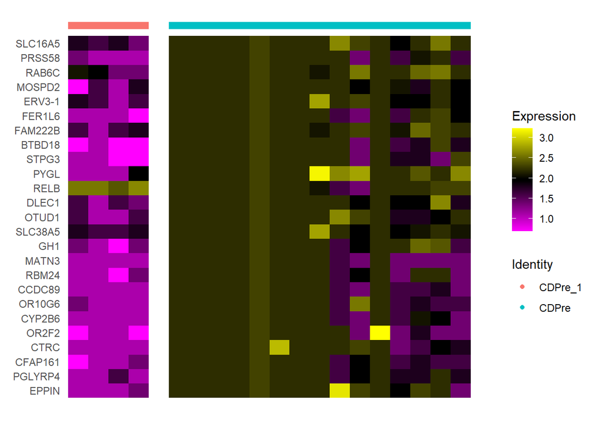

```r
DoHeatmap(object=objSeurat[,jjj],features=row.names(top10s),assay="SCT",slot="data",size=2.5,draw.lines=T,label=F)
```